# 統繪R筆記整理

# H24074035 統計111 李瑞庭

## basic

### calculator

-相加(+), 相乘(*), 相除(/)  
-let a/b = c + d, c is a quotient and d is a remainder. we denote :

```
c = a %/% b
d = a %% b
```

### express a sequence

normal sequence : use “a:b”, “seq(a,b)”  
others:

```r
seq(1,10,2)
```

```
## [1] 1 3 5 7 9
```

```r
seq(1,10, by = 2)
```

```
## [1] 1 3 5 7 9
```

```r
seq(1,10, length.out = 6)
```

```
## [1]  1.0  2.8  4.6  6.4  8.2 10.0
```

### special values in R

| notation | meaning |
| --- | --- |
| NA | missing value |
| NaN | 0/0 |
| Inf | 2/0 |

```r
Inf+NaN ; Inf+NA ; NaN+NA ; Inf+Inf+10
```

```
## [1] NaN
```

```
## [1] NA
```

```
## [1] NaN
```

```
## [1] Inf
```

### approximated values

```r
round(123.98765)
```

```
## [1] 124
```

```r
round(123.98765, digits = 3)
```

```
## [1] 123.988
```

```r
round(123.98765, digits = -2)
```

```
## [1] 100
```

note : round 代表去掉小數的部分且進位，digits為設定進位的位數

```r
signif(1928373, digits = 2)
```

```
## [1] 1900000
```

```r
signif(1928373, digits = 5)
```

```
## [1] 1928400
```

```r
signif(1928.373, digits = 2)
```

```
## [1] 1900
```

### other mathematical functions

```r
abs(-2)
```

```
## [1] 2
```

```r
sqrt(25)
```

```
## [1] 5
```

```r
ceiling(4.87); ceiling(4.23)
```

```
## [1] 5
```

```
## [1] 5
```

```r
floor(2.7); floor(2.1)
```

```
## [1] 2
```

```
## [1] 2
```

```r
trunc(9.344); trunc(9.123)
```

```
## [1] 9
```

```
## [1] 9
```

```r
cos(30); acos(30); cosh(30); acosh(30)
```

```
## [1] 0.1542514
```

```
## [1] NaN
```

```
## [1] 5.343237e+12
```

```
## [1] 4.094067
```

```r
log(10, base = 10); log10(10)
```

```
## [1] 1
```

```
## [1] 1
```

```r
exp(10)
```

```
## [1] 22026.47
```

note : function of cot(x), acot(x) needs to install pracma

### descriptive statistics

```r
x <- c(1:25, NA)
mean(x); mean(x, na.rm = T)
```

```
## [1] NA
```

```
## [1] 13
```

```r
var(x); var(x, na.rm = T)
```

```
## [1] NA
```

```
## [1] 54.16667
```

```r
median(x); median(x, na.rm = T)
```

```
## [1] NA
```

```
## [1] 13
```

```r
#quantile(x, 0.5)-> Error in quantile.default(x, 0.5): missing values and NaN's
quantile(x, 0.5, na.rm = T)
```

```
## 50%
##  13
```

```r
summary(x)
```

```
##    Min. 1st Qu.  Median    Mean 3rd Qu.    Max.    NA's
##       1       7      13      13      19      25       1
```

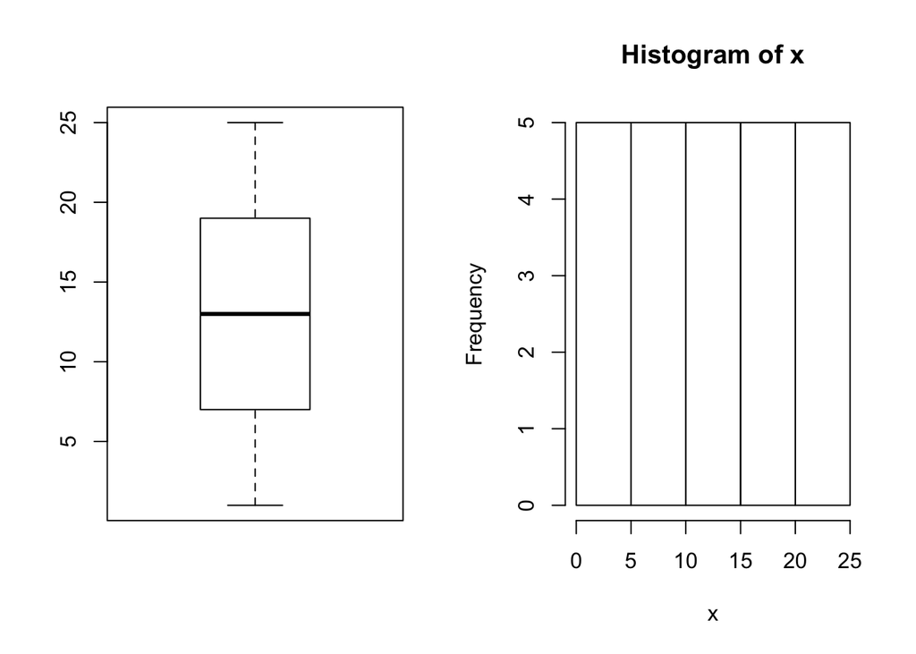

```r
par(mfrow = c(1,2))
boxplot(x)
hist(x)
```

note : na.rm means remove NAs from the sequence.

### take a look at your workspace

```r
objects()
```

```
## [1] "x"
```

```r
ls()
```

```
## [1] "x"
```

if you want to delete x and y from object, type

“rm(x, y)”

after doing this, you can retype “object()” to check.

## vectors

### basic

```r
#create
vt1 <- c(1:5); vt2 <- c(2,4)
#combine
vt3 <- c(vt1, vt2)
#instead of typing "vt2<-c(vt2,vt1)", "vt3<-c(vt2, vt1)" is a safer way.

#check how many elements in the vector
length(vt1)
```

```
## [1] 5
```

```r
#select the locations in the vector
vt1[1]; vt1[c(1,3,4)]
```

```
## [1] 1
```

```
## [1] 1 3 4
```

```r
#remove the third location of the vector
vt1[-3]
```

```
## [1] 1 2 4 5
```

```r
#or remove not just one location
vt1[-c(2:4)]
```

```
## [1] 1 5
```

### vector arithmetic

```r
x<-c(3,6,9)
x*3; x-3; x^3
```

```
## [1]  9 18 27
```

```
## [1] 0 3 6
```

```
## [1]  27 216 729
```

```r
y1<-c(3,2); y2<-c(3,2,4)

#deffrient length
x^y1
```

```
## [1]  27  36 729
```

```r
x^y2
```

```
## [1]   27   36 6561
```

```r
#when the vectors are different lengths, the shorter one is extended by recycling.
c(1,1,2,2,3,3,4,4,5,5,6,6,7,7,8,8,9,9,10,10) %% 2:3
```

```
##  [1] 1 1 0 2 1 0 0 1 1 2 0 0 1 1 0 2 1 0 0 1
```

```r
c(1,1,2,2,3,3,4,4,5,5,6,6,7,7,8,8,9,9,10,10) %% rep(2:3, 10)
```

```
##  [1] 1 1 0 2 1 0 0 1 1 2 0 0 1 1 0 2 1 0 0 1
```

```r
#assign values into a vector
vtx<- rep(NA, 6)
vtx[2]<-5
vtx[c(4:6)] <- rep(1, 3)
vtx
```

```
## [1] NA  5 NA  1  1  1
```

```r
#to delete NA
vtx[-c(1,3)]
```

```
## [1] 5 1 1 1
```

```r
vtxnew <- vtx[-c(1,3)]
vtxnew
```

```
## [1] 5 1 1 1
```

## matrix

construct a matrix

```r
a <- 1:5; b <- 6:10; c <- 11:15; d <- 16:20
#1
matr1 <- rbind(a,b,c,d)
matr1
```

```
##   [,1] [,2] [,3] [,4] [,5]
## a    1    2    3    4    5
## b    6    7    8    9   10
## c   11   12   13   14   15
## d   16   17   18   19   20
```

```r
dim(matr1)
```

```
## [1] 4 5
```

```r
#2
matr2 <- cbind(a,b,c,d)
matr2
```

```
##      a  b  c  d
## [1,] 1  6 11 16
## [2,] 2  7 12 17
## [3,] 3  8 13 18
## [4,] 4  9 14 19
## [5,] 5 10 15 20
```

```r
dim(matr2)
```

```
## [1] 5 4
```

```r
#3
#note the ordering
x <- 1:6
matrix(x, nrow = 2, ncol = 3)
```

```
##      [,1] [,2] [,3]
## [1,]    1    3    5
## [2,]    2    4    6
```

```r
matrix(x, nrow = 2, ncol = 3, byrow = TRUE)
```

```
##      [,1] [,2] [,3]
## [1,]    1    2    3
## [2,]    4    5    6
```

```r
#note the index
xnew<-matrix(x, nrow = 2, ncol = 3, byrow = TRUE)
xnew
```

```
##      [,1] [,2] [,3]
## [1,]    1    2    3
## [2,]    4    5    6
```

```r
xnew[2]; xnew[5]
```

```
## [1] 4
```

```
## [1] 3
```

```r
#we can change the column or row names by :
colnames(matr1); rownames(matr1); dimnames(matr1);
```

```
## [1] "a" "b" "c" "d"
```

```
## [[1]]
## [1] "a" "b" "c" "d"
##
## [[2]]
## NULL
```

```r
colnames(matr1) <- c("V1","V2","V3","V4","V5")
matr1
```

```
##   V1 V2 V3 V4 V5
## a  1  2  3  4  5
## b  6  7  8  9 10
## c 11 12 13 14 15
## d 16 17 18 19 20
```

指定矩陣內元素

```r
m<-1:12
matrix(m, ncol = 3, nrow = 4)
```

```
##      [,1] [,2] [,3]
## [1,]    1    5    9
## [2,]    2    6   10
## [3,]    3    7   11
## [4,]    4    8   12
```

```r
mat<-matrix(m, ncol = 3, nrow = 4)
mat[2,1];
```

```
## [1] 2
```

```r
mat[c(2,3), 2]; mat[c(1:2), c(2,3)];
```

```
## [1] 6 7
```

```
##      [,1] [,2]
## [1,]    5    9
## [2,]    6   10
```

```r
mat[, 3]; mat[c(1:2), ]
```

```
## [1]  9 10 11 12
```

```
##      [,1] [,2] [,3]
## [1,]    1    5    9
## [2,]    2    6   10
```

to view the summary of each column or each row

```r
c<-matrix(1:9,3,3)
colSums(c)
```

```
## [1]  6 15 24
```

```r
rowSums(c)
```

```
## [1] 12 15 18
```

```r
colMeans(c)
```

```
## [1] 2 5 8
```

```r
rowMeans(c)
```

```
## [1] 4 5 6
```

transpose

```r
t(c)
```

```
##      [,1] [,2] [,3]
## [1,]    1    2    3
## [2,]    4    5    6
## [3,]    7    8    9
```

diagonal matrix

```r
diag(c)
```

```
## [1] 1 5 9
```

determinant of a matrix

```r
det(c)
```

```
## [1] 0
```

find the inverse

solve(c) ->Error in solve.default(c) : Lapack routine dgesv : system is exactly singular : U[3,3] = 0

the matrix c do not have an inverse since det(c) = 0

eigen system

```r
B <- matrix(c(5:8), 2, 2)
eigen(B)
```

```
## eigen() decomposition
## $values
## [1] 13.1520673 -0.1520673
##
## $vectors
##            [,1]       [,2]
## [1,] -0.6514625 -0.8053759
## [2,] -0.7586809  0.5927644
```

```r
D <- matrix(rnorm(9), 3, 3)
eig.D <- eigen(D)
eig.D$values
```

```
## [1]  2.74765835 -1.91460332 -0.06610087
```

## for loop

random number generator

```r
x0 <- 3; a <- 5; c <- 7; m <- 501
X <- rep(NA, 11)
X[1] <- x0
for(j in 1:10){
  X[j + 1] <- (a*X[j] + c) %% m
  }
X[2:11]
```

```
##  [1]  22 117  91 462 313  69 352 264 325 129
```

## if() statement

Count the number of each class

```r
basket <- c("r", "b", "y", "y", "y", "r", "r", "b")
n.r <- 0; n.b <- 0; n.y <- 0
for(i in 1:length(basket)){
  if(basket[i] == "r"){ n.r <- n.r + 1
  }else if(basket[i] == "b"){
    n.b <- n.b + 1
  }else{
  n.y <- n.y + 1
  }
}
c(n.r, n.b, n.y)
```

```
## [1] 3 2 3
```

## while() loop

the following is an example applying for loop

```r
for(j in 1:8){
  print(j)
}
```

```
## [1] 1
## [1] 2
## [1] 3
## [1] 4
## [1] 5
## [1] 6
## [1] 7
## [1] 8
```

compare to the above example, the following is an example applying while loop.  
the while loop needs the initial, condition of stopping, and iteration or replacement.

```r
j <- 1
while(j <= 8){
  print(j)
  j <- j + 1
}
```

```
## [1] 1
## [1] 2
## [1] 3
## [1] 4
## [1] 5
## [1] 6
## [1] 7
## [1] 8
```

Fibonacci numbers  
1. using while loop

```r
Fib1 <- 1
Fib2 <- 1
Fibonacci <- c(Fib1)
while (Fib2 < 100) {
  Fibonacci <- c(Fibonacci, Fib2)
  Fib1 <- Fibonacci[length(Fibonacci) - 1]
  Fib2 <- Fib1 + Fibonacci[length(Fibonacci)]
}
Fibonacci
```

```
##  [1]  1  1  2  3  5  8 13 21 34 55 89
```

2.using “break”

```r
Fib1 <- 1
Fib2 <- 1
Fibonacci <- c(Fib1)
for(j in 1:1000){
  if(Fib2 < 100){
    Fibonacci <- c(Fibonacci, Fib2)
    Fib1 <- Fibonacci[length(Fibonacci) - 1]
    Fib2 <- Fib1 + Fibonacci[length(Fibonacci)]
}else{
  break
  }
}
Fibonacci
```

```
##  [1]  1  1  2  3  5  8 13 21 34 55 89
```

3.using “repeat” and “break”

```r
Fib1 <- 1
Fib2 <- 1
Fibonacci <- c(Fib1)
repeat
{
  if(Fib2 < 100){
    Fibonacci <- c(Fibonacci, Fib2)
    Fib1 <- Fibonacci[length(Fibonacci) - 1]
    Fib2 <- Fib1 + Fibonacci[length(Fibonacci)]
  }else{
    break
  }
}
Fibonacci
```

```
##  [1]  1  1  2  3  5  8 13 21 34 55 89
```

4. using “repeat{}” and “break”

```r
Fib1 <- 1
Fib2 <- 1
Fibonacci <- c(Fib1)
repeat
{
  if(Fib2 >= 100) break
    Fibonacci <- c(Fibonacci, Fib2)
    Fib1 <- Fibonacci[length(Fibonacci) - 1]
    Fib2 <- Fib1 + Fibonacci[length(Fibonacci)]
}
Fibonacci
```

```
##  [1]  1  1  2  3  5  8 13 21 34 55 89
```

```r
Fib1 <- 1
Fib2 <- 1
Fibonacci <- c(Fib1)
for(j in 1:100){
  if(Fib2 >= 100) next
    Fibonacci <- c(Fibonacci, Fib2)
    Fib1 <- Fibonacci[length(Fibonacci) - 1]
    Fib2 <- Fib1 + Fibonacci[length(Fibonacci)]
#print(j)
}
Fibonacci
```

```
##  [1]  1  1  2  3  5  8 13 21 34 55 89
```

### print()

```r
k <- 1
while(k < 100){
  fac <- c()
  for(j in 1:k){
    if((k %% j) == 0) fac <- c(fac, j)
  }
  if(k == sum(fac[-length(fac)])){
    out <- paste(paste(k, "=", sep=" "),
                 paste(fac[-length(fac)], collapse = " + "), sep = " ")
    print(out)
  }
  k <- k+1
}
```

```
## [1] "6 = 1 + 2 + 3"
## [1] "28 = 1 + 2 + 4 + 7 + 14"
```

### cat()

```r
k <- 1
while(k < 100){
  fac <- c()
  for(j in 1:k){
    if((k %% j) == 0){
      fac <- c(fac, j)
    }
  }
  if(k == sum(fac[-length(fac)])){
    cat(paste(k, "=", sep=" "),
        paste(fac[-length(fac)], collapse = " + "), "\n")
    }
  k <- k+1
}
```

```
## 6 = 1 + 2 + 3
## 28 = 1 + 2 + 4 + 7 + 14
```

### function

if we want a function like this :  
f(x)=3x+2, x=2,3,4. we can represent it by :

```r
 f <- function(x){
   3*x + 2
}
f(2); f(3); f(4)
```

```
## [1] 8
```

```
## [1] 11
```

```
## [1] 14
```

another example

```r
f <- function(x){
  res <- 3*x + 2
}
f(2)
```

-> return nothing, so we add :

```r
f <- function(x){
  res <- 3*x + 2
}
f(2)
a<- f(2); a
```

```
## [1] 8
```

or a better way, by using “return()”

```r
 f <- function(x){
   return(3*x + 2)
}
f(2)
```

```
## [1] 8
```

example : perfect number

```r
perfect.number <- function(a, b){
  k <- a
  res <- c()
  while(k < b){
    fac <- c()
    for(j in 1:k){
      if((k %% j) == 0) fac <- c(fac, j)
    }
    if(k == sum(fac[-length(fac)])) {
      res <- c(res, k)}
      k <- k+1
  }
  return(res)
}
perfect.number(10, 10000)
```

```
## [1]   28  496 8128
```

### list()

a collection of multiple types of objects, like vectors, characteristics, numbers, lists,…

```r
X <- list(a = 3, b = c(1,2,3,4,5), c = c("A", "B"))
X
```

```
## $a
## [1] 3
##
## $b
## [1] 1 2 3 4 5
##
## $c
## [1] "A" "B"
```

### $ or [[]]

$ : the name of the element.  
[[]] : the location or the name of the element.

```r
 X <- list(a = 3, b = c(1,2,3,4,5), c = c("A", "B"))
X$a; X[[2]]; X[["c"]]
```

```
## [1] 3
```

```
## [1] 1 2 3 4 5
```

```
## [1] "A" "B"
```

use function and list

```r
perfect.number <- function(a, b){
  k <- a
  res <- c()
  ans <- list()
  while(k < b){
    fac <- c()
    for(j in 1:k){
      if((k %% j) == 0) fac <- c(fac, j)
    }
    if(k == sum(fac[-length(fac)])) {
      res <- c(res, k)
      ans[[paste(k)]] <- fac[-length(fac)]
  }
k <- k+1
}
ans$number <- res
return(ans)
}
Ans<- perfect.number(1,100)
Ans
```

```
## $`6`
## [1] 1 2 3
##
## $`28`
## [1]  1  2  4  7 14
##
## $number
## [1]  6 28
```

partially shown multiple output

use “invisible()” to hide some output

```r
perfect.number <- function(a, b){
  k <- a
  res <- c()
  ans <- list()
  while(k < b){
    fac <- c()
    for(j in 1:k){
      if((k %% j) == 0) fac <- c(fac, j)
    }
    if(k == sum(fac[-length(fac)])) {
      res <- c(res, k)
      ans[[paste(k)]] <- fac[-length(fac)]
    }
      k <- k+1
}
print(res)
ans$number <- res
return(invisible(ans))
 }
Ans <- perfect.number(1, 100)
```

```
## [1]  6 28
```

```r
Ans
```

```
## $`6`
## [1] 1 2 3
##
## $`28`
## [1]  1  2  4  7 14
##
## $number
## [1]  6 28
```

```r
length(Ans)
```

```
## [1] 3
```

## data frame

Most data sets are stored in R as data frames.

These are like matrices, but with the columns having their own names.

Columns can be of different types from each other.

an example of matrix :

```r
X <- matrix(NA, 3, 3)
X[,1] <- c("red", "yellow", "blue")
X[,2] <- c(1, 2, 3)
X[,3] <- c(4, 5, 6)
colnames(X) <- c("colors", "numbers", "more.numbers")
X
```

```
##      colors   numbers more.numbers
## [1,] "red"    "1"     "4"
## [2,] "yellow" "2"     "5"
## [3,] "blue"   "3"     "6"
```

use data frame :

```r
colors <- c("red", "yellow", "blue")
numbers <- c(1, 2, 3)
colors.and.numbers<-data.frame(colors,numbers,more.numbers = c(4, 5, 6))
colors.and.numbers
```

```
##   colors numbers more.numbers
## 1    red       1            4
## 2 yellow       2            5
## 3   blue       3            6
```

## graphics

an example of graphices :

[figure not shown]

```r
#graph1
par(mfrow=c(2,2))
k<-c(0:10)
plot(k,dbinom(k,size = 10,prob = .2),ylim=c(0.0,0.4), type = "h", xlab = "x",ylab = "pdf", col = "red", lty =2 )
par(new=TRUE)
plot(k,dbinom(k,size = 10, prob = .5),ylim=c(0.0,0.4),type = "h",xlab = "x",ylab = "pdf",col = "blue", lty = 4)
legend("topright", c("p = 0.7", "p = 0.5", "p = 0.2"),
       col = c("black", "blue", "red"), lty = c(1,4,2) ,pch = c(19,8,17))
par(new=TRUE)
plot(k,dbinom(k,size = 10, prob = .7),ylim=c(0.0,0.4),type = "h",xlab = "x",ylab = "pdf", col = "black", lty = 1)
par(new = TRUE)
plot(k,dbinom(k,size = 10,prob = .2),ylim=c(0.0,0.4), type = "p", xlab = "x",ylab = "pdf", col = "red", lty =2 , pch = 17)
par(new=TRUE)
plot(k,dbinom(k,size = 10, prob = .5),ylim=c(0.0,0.4),type = "p",xlab = "x",ylab = "pdf",col = "blue", lty = 4, pch = 8)
par(new=TRUE)
plot(k,dbinom(k,size = 10, prob = .7),ylim=c(0.0,0.4),type = "p",xlab = "x",ylab = "pdf", col = "black", lty = 1, pch = 19)
title("binomial(n,p) with n = 10")

#graph2

curve(dgamma(x,1,3), 0, 5,ylim=c(0.0,3.0),lty=1,col="black",main=expression(paste("Gamma(",alpha,",", lambda,") with ",lambda," = 3")),ylab="pdf")
curve(dgamma(x,2,3), 0, 5,ylim=c(0.0,3.0),lty=2,col="red", add = TRUE)
curve(dgamma(x,3,3), 0, 5,ylim=c(0.0,3.0),lty=4,col="blue", add = TRUE)
curve(dgamma(x,5,3), 0, 5,ylim=c(0.0,3.0),lty=5,col="gray", add = TRUE)
legend("topright", c(expression(paste(alpha, " = 1")),expression(paste(alpha, " = 2")),expression(paste(alpha, " = 3")),expression(paste(alpha, " = 5"))),col = c("black","red","blue","gray"),text.col = c(1,1,1,1),lty = c(1,2,4,5))

#graph3
curve(dnorm(x, 5, sd = 1),0,20 ,col = "black", lty = 1, main = expression(paste("N(",mu,",",sigma^2,") with ",sigma^2," = 1")),ylab = "pdf")
curve(dnorm(x, 10, sd = 1),0,20, col = "red", lty = 2, add = TRUE)
curve(dnorm(x, 12, sd = 1),0,20, col = "blue", lty = 4, add = TRUE)
curve(dnorm(x, 14, sd = 1),0,20, col = "gray", lty = 5, add = TRUE)
legend("topright", c(expression(paste(sigma, " = 0.5")),expression(paste(sigma, " = 1")),expression(paste(sigma, " = 2")),expression(paste(sigma, " = 3"))),col = c("black","red","blue","gray"),text.col = c(1,1,1,1),lty = c(1,2,4,5))

#graph4
curve(dnorm(x, 0, sd = 0.5),-9,9 ,col = "black", lty = 1, main = expression(paste("N(",mu,",",sigma^2,") with ",mu," = 0")),ylab = "pdf")
curve(dnorm(x, 0, sd = 1),-9,9, col = "red", lty = 2, add = TRUE)
curve(dnorm(x, 0, sd = 2),-9,9, col = "blue", lty = 4, add = TRUE)
curve(dnorm(x, 0, sd = 3),-9,9, col = "gray", lty = 5, add = TRUE)
legend("topright", c(expression(paste(sigma, " = 0.5")),expression(paste(sigma, " = 1")),expression(paste(sigma, " = 2")),expression(paste(sigma, " = 3"))),col = c("black","red","blue","gray"),text.col = c(1,1,1,1),lty = c(1,2,4,5))
```

### R markdown

#### introduce R Markdown

Compile a single R Markdown document to a report in different formats, such as PDF, HTML, or Word.

Create notebooks in which you can directly run code chunks interactively.

Make slides for presentations (HTML5, LaTeX Beamer, or PowerPoint).

##### you have to “install.packages(”rmarkdown“)” first

-> start from creating a new file .Rmd

##### basic editings

*italics* and *italics* **bold** and **bold** superscript<sup>2</sup> strikethrough

##### headers of a paragraph :

# Header 1

## Header 2

### Header 3

#### Header 4

##### Header 5

###### Header 6

##### equations

$A = \pi*r^{2}$

center an equation :

$$B = 2 \pi r$$

##### bullet point

- unordered list * item 2
- sub-item 1
1. ordered list
2. item 2
- sub-item 1

##### table

| Table Header | Second Header |
| --- | --- |
| Table Cell | Cell 2 |
| Cell 3 | Cell 4 |

##### matrix

$\left[ \begin{array}{cc} A & B \\ C & D \\ \end{array} \right]$

##### inline r codes

6

##### showing an existed figure

```r
#<center>
#![EDA](EDA_Graphics.png){width=50%}
#<center>
```

### apply family

#### apply(…)

##### apply(X, MARGIN, FUN, . . . )

Returns a vector or array or list of values obtained by applying a function to margins of an array or a matrix.

- X: array or matrix (or a data frame) *
- MARGIN: for a matrix 1 indicates rows, 2 indicates columns *
- FUN: name of a function *

#### lapply(…)

##### lapply(X, FUN, . . . )

Returns a list of the same length as X, each element of which is the result of applying FUN to the corresponding element of X. * X: vector or data frame or list *  
* FUN: name of a function *

#### sapply(…)

##### sapply(X, FUN, . . . , simplify = TRUE)

Similarlly to lapply(X, Fun, . . . ) if sapply(x, f, simplify = FALSE, USE.NAMES = FALSE)

- X: vector or data frame or list*
- FUN: name of a function *
- simplify: logical; TRUE will return an array or a matrix with the same length of output *